# Exam example2

Anahita Esfandiaryfard

# Question1

```r
str(infert)
```

```
'data.frame':   248 obs. of  8 variables:
 $ education     : Factor w/ 3 levels "0-5yrs","6-11yrs",..: 1 1 1 1 2 2 2 2 2 2 ...
 $ age           : num  26 42 39 34 35 36 23 32 21 28 ...
 $ parity        : num  6 1 6 4 3 4 1 2 1 2 ...
 $ induced       : num  1 1 2 2 1 2 0 0 0 0 ...
 $ case          : num  1 1 1 1 1 1 1 1 1 1 ...
 $ spontaneous   : num  2 0 0 0 1 1 0 0 1 0 ...
 $ stratum       : int  1 2 3 4 5 6 7 8 9 10 ...
 $ pooled.stratum: num  3 1 4 2 32 36 6 22 5 19 ...
```

The dataframe contains 248 data and 8 variables.We can check if there are any na value as follows,

```r
any(is.na(infert))
```

```
[1] FALSE
```

The dataframe does not contain any na values.

# Question2

```r
aggregate(infert['age'], list(education=infert$education), mean)
```

| education | age |
| --- | --- |
| 0-5yrs | 35.25000 |
| 6-11yrs | 32.85000 |
| 12+ yrs | 29.72414 |

the group containing the older subject is 0-5yrs.

# Question 3

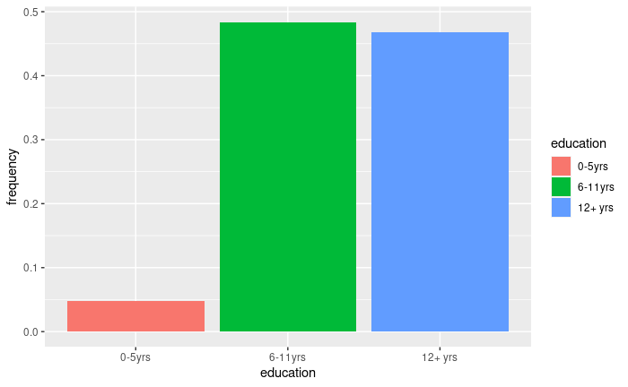

```r
library(ggplot2)
ggplot(infert, aes(x=education, fill=education))+geom_bar(aes(y=..count../sum(..count..)))+ ylab("frequency")
```

according to bar plot class 6-11 yrs has more subject.

# Question 4

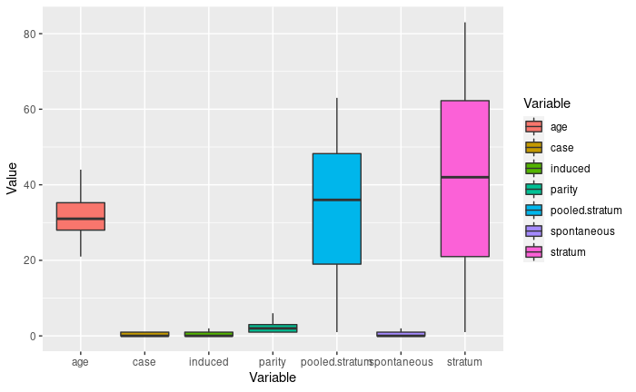

```r
library(tidyr)
infert.long <- gather(infert, key='Variable', value='Value',
    age, parity, induced, case, spontaneous, stratum, pooled.stratum
)

ggplot(infert.long, aes(x=Variable, y=Value, fill=Variable)) +
  geom_boxplot()
```

Since the variables vart different range it is better to split the boxplot into two parts:

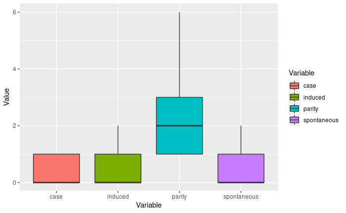

```r
ggplot(subset(infert.long,
              Variable %in% c("case", "induced", 'parity', 'spontaneous')),
       aes(x=Variable, y=Value, fill=Variable)) +
  geom_boxplot()
```

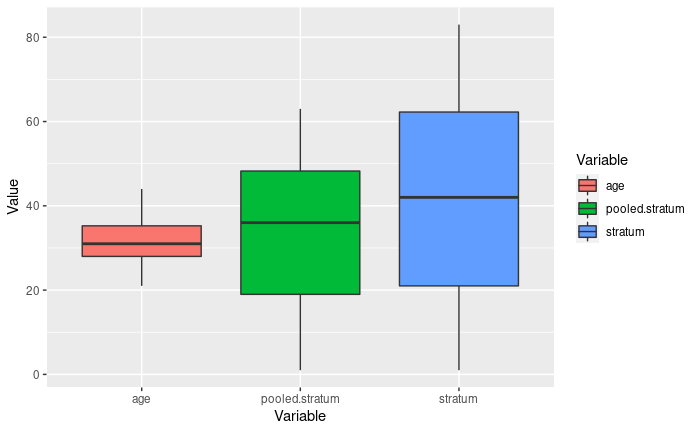

```r
ggplot(subset(infert.long,
              Variable %in% c("age", "pooled.stratum", 'stratum')),
       aes(x=Variable, y=Value, fill=Variable)) +
  geom_boxplot()
```

The distributions of `age` and `stratum` are overall symetric. Indeed, the box and the whiskers are symmetric with respect to the median value. `case`, `induced` and `spontaneous` are not symmetrical. `pooled.stratum` is not perfectly symmetric but still not completly asymmetric. `parity` is not symmetric because the bottom whisker does not extend below the box.

None of the variables has outliers.

# Question 5

The following code compute the correlation matrix.removing the first columns which are factors:

```r
(c <- cor(infert[-c(1)]))
```

```
                        age       parity    induced        case spontaneous
age             1.000000000  0.082795117 -0.1008192 0.003530451 -0.08427289
parity          0.082795117  1.000000000  0.4460919 0.008910762  0.31238542
induced        -0.100819200  0.446091853  1.0000000 0.017112002 -0.26852622
case            0.003530451  0.008910762  0.0171120 1.000000000  0.36399763
spontaneous    -0.084272890  0.312385422 -0.2685262 0.363997632  1.00000000
stratum        -0.210093427 -0.311240878 -0.1007998 0.003825897  0.06074804
pooled.stratum -0.174769382  0.119989464  0.1626926 0.004861419  0.21277781
                    stratum pooled.stratum
age            -0.210093427   -0.174769382
parity         -0.311240878    0.119989464
induced        -0.100799751    0.162692616
case            0.003825897    0.004861419
spontaneous     0.060748045    0.212777807
stratum         1.000000000    0.753010702
pooled.stratum  0.753010702    1.000000000
```

To easily check what is the strongest relationship, I will use corrplot:

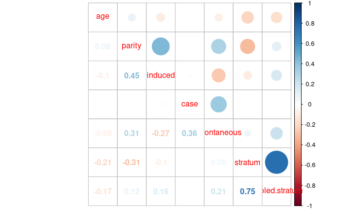

```r
library(corrplot)
corrplot.mixed(c)
```

- `stratum` - `pooled.stratum`: this is a strong correlation, with a correlation coefficient of $0.75$;
- `parity` - `induced`: this is a moderate correlation, with a correlation coefficient of $0.45$;
- `case` - `spontaneous`: this is a moderate correlation, with a correlation coefficient of $0.36$;
- `parity` - `spontaneous`: this is a moderate correlation, with a correlation coefficient of $0.31$;

The other positive correlations are weak (below $0.3$).

The strongest negative correlation is:

- `stratum` - `parity`: this is a moderate negative correlation, with a correlation coefficient of $-0.31$;

The other negative correlations are weak (absolute value below $0.3$).

# Question 6

```r
cor.test(infert$induced, infert$parity)
```

```
    Pearson's product-moment correlation

data:  infert$induced and infert$parity
t = 7.8176, df = 246, p-value = 1.573e-13
alternative hypothesis: true correlation is not equal to 0
95 percent confidence interval:
 0.3404426 0.5406177
sample estimates:
      cor
0.4460919
```

# Question 7

Let us compute the table of proportion for case:

```r
counts <- table(infert$case)
prop.table(counts)
```

```
        0         1
0.6653226 0.3346774
```

The proportion of observations for which `case=0` is $0.67$. We can run a statistical test to check if this estimated proportion is significantly different than $0.5$.

```r
prop.test(counts, p=0.5)
```

```
    1-sample proportions test with continuity correction

data:  counts, null probability 0.5
X-squared = 26.456, df = 1, p-value = 2.697e-07
alternative hypothesis: true p is not equal to 0.5
95 percent confidence interval:
 0.6023965 0.7230336
sample estimates:
        p
0.6653226
```

The p-value is below the significance threshold, so we accept the alternative hypothesis that the observations are not evenly distributed with respect to case.

# Question 8

```r
(reg <- lm(parity ~ induced, infert))
```

```
Call:
lm(formula = parity ~ induced, data = infert)

Coefficients:
(Intercept)      induced
      1.660        0.756
```

If we observe a value of `induced` increased by $1$ unit, we would expect to observe an increment of `parity` by $0.756$ units.

# Question 9

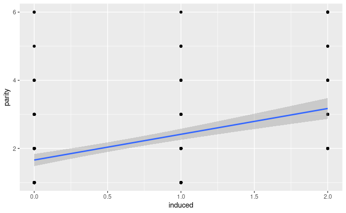

```r
ggplot(infert, aes(x=induced, y=parity))+ geom_point()+geom_smooth(method = lm)
```

# Question 10

```r
summary(reg)
```

```
Call:
lm(formula = parity ~ induced, data = infert)

Residuals:
    Min      1Q  Median      3Q     Max
-1.4159 -0.6599 -0.4159  0.3401  4.3401

Coefficients:
            Estimate Std. Error t value Pr(>|t|)
(Intercept)  1.65986    0.09025  18.391  < 2e-16 ***
induced      0.75602    0.09671   7.818 1.57e-13 ***
---
Signif. codes:  0 ‘***’ 0.001 ‘**’ 0.01 ‘*’ 0.05 ‘.’ 0.1 ‘ ’ 1

Residual standard error: 1.122 on 246 degrees of freedom
Multiple R-squared:  0.199, Adjusted R-squared:  0.1957
F-statistic: 61.12 on 1 and 246 DF,  p-value: 1.573e-13
```

We will also display the residual plot to check if the regressor is a good fit:

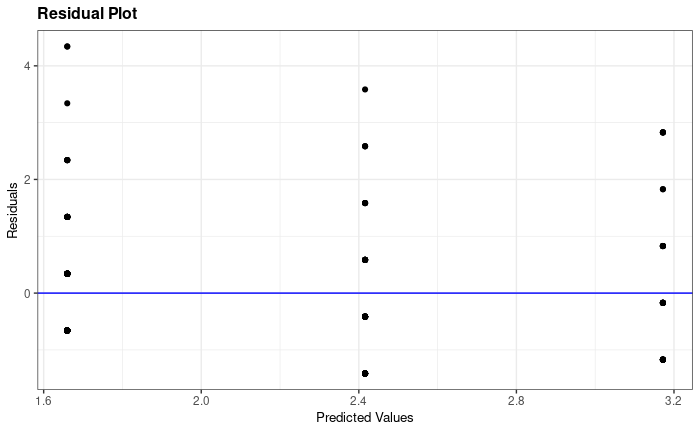

```r
library(ggResidpanel)
resid_panel(reg, plots='resid')
```

From the residual plot, it is clear that the fit is not good. Indeed, the residuals do follow a pattern (they are not random) and they are not small. This is also confirmed by the $R^2$ which is below $0.2$.

Even if the regressor is not a good fit, it is statistically significant. This can be assessed by observing that the p-value of the F-test is below the significance threshold of $0.05$. Also, all the paramter estimates are statistically significant (p-values below $0.05$).